# Aidan Feliciano

### Draft NAs

When players go undrafted but later play in the NBA, draft_year, draft_round, draft_pick, and draft_team will be NA. So, I will convert the NAs for all "draft_columns" to "Undrafted"

```python
# Return NAs for draft columns
draft_columns = ["draft_year", "draft_round", "draft_pick", "draft_team", "draft_age"]
print(players_clean[draft_columns].isna().sum())
```

```
draft_year     1244
draft_round     148
draft_pick     1362
draft_team     1178
draft_age      1244
dtype: int64
```

```python
# Filling the NAs in the draft_columns with "Undrafted"
players_clean[draft_columns] = players_clean[draft_columns].fillna("Undrafted")
print(players_clean[draft_columns].isna().sum())
```

```
draft_year     0
draft_round    0
draft_pick     0
draft_team     0
draft_age      0
dtype: int64
```

### College

```python
players_clean["college"].isna().sum()
```

```
313
```

```python
# Converting the 313 NaN values to "None"
players_clean["college"] = players_clean["college"].fillna("None")
```

```python
# Get value counts of colleges
players_clean["college"].value_counts()
```

```
college
None                                                    313
University of Kentucky                                  102
University of California, Los Angeles                    90
University of North Carolina                             88
Duke University                                          75
                                                       ...
Wheeling Jesuit University                                1
University of Northern Colorado                           1
Ashland University                                        1
Jacksonville University, University of Houston            1
Seattle Pacific University, University of Washington      1
Name: count, Length: 732, dtype: int64
```

We can see that there are a lot of colleges with commas that are not indicative of separate schools: "University of California, Los Angeles" is one school, while "Jacksonville University" and "University of Houston" are two schools, separated by a comma.

```python
# List of colleges I found to have commas to specify the location (almost all CA and NV state schools)
replacement_schools = ["University of California, Los Angeles",  "University of Nevada, Las Vegas",
                           "California State University, Long Beach", "California State University, Fresno",
                           "University of Nevada, Reno","California State University, Fullerton",
                           "University of California, Santa Barbara", "University of California, Irvine",
                           "California State University, Los Angeles", "University of California, Riverside",
                           "California State University, San Bernadino", "California State University, Northridge",
                           "California Polytechnic State University, San Luis Obispo", "University at Buffalo, State University of New York",
                           "California State University, Bakersfield"]


# Key to replace above list with the name of the school sans comma
replacement_schools_key = ["University of California Los Angeles",  "University of Nevada Las Vegas",
                           "California State University Long Beach", "California State University Fresno",
                           "University of Nevada Reno","California State University Fullerton",
                           "University of California Santa Barbara", "University of California Irvine",
                           "California State University Los Angeles", "University of California Riverside",
                           "California State University San Bernadino", "California State University Northridge",
                           "California Polytechnic State University San Luis Obispo", "State University of New York College at Buffalo",
                           "California State University Bakersfield"]

# Loop through the "college" column in the dataframe to replace the colleges' names
for orig, repl in zip(replacement_schools, replacement_schools_key):
    players_clean["college"] = players_clean["college"].str.replace(orig, repl)

# Create list of the updated colleges
colleges = players_clean["college"]

# Split the colleges by column to reflect players attending multiple schools
colleges = colleges.str.split(", ", expand=True)

# Join new dataframe to main dataframe
players_clean = pd.concat([players_clean, colleges], axis = 1)

# Drop original "college" column
players_clean = players_clean.drop("college", axis = 1)

# Rename new college columns
players_clean.rename(columns= {0 : "college_1", 1 : "college_2", 2 : "college_3", 3 : "college_4"}, inplace=True)
```

```python
# Check that no new college columns have any values with a comma
print(players_clean["college_1"].str.contains(", ").sum())
print(players_clean["college_2"].str.contains(", ").sum())
print(players_clean["college_3"].str.contains(", ").sum())
print(players_clean["college_4"].str.contains(", ").sum())
```

```
0
0
0
0
```

```python
# Checking the college columns for NA values
print(players_clean[["college_1", "college_2", "college_3", "college_4"]].isna().sum())

# Filling NA values in the college columns with "None"
players_clean["college_1"] = players_clean["college_1"].fillna("None")
players_clean["college_2"] = players_clean["college_2"].fillna("None")
players_clean["college_3"] = players_clean["college_3"].fillna("None")
players_clean["college_4"] = players_clean["college_4"].fillna("None")
```

```
college_1       0
college_2    4406
college_3    4676
college_4    4684
dtype: int64
```

### Height

```python
players_clean["height"] # This should be either two columns: height (feet) and height (inches), or just one column: height (inches)
```

```
0       6-10
1        6-9
2        7-2
3        6-1
4        6-6
        ...
4680    6-11
4681     7-1
4682     6-1
4683     7-1
4684     6-3
Name: height, Length: 4685, dtype: object
```

```python
height = players_clean["height"]
height = height.str.split("-", expand=True) # I think total height in inches is best
height = height.astype("float")

height["total_height_inches"] = ((height[0] * 12) + height[1]).astype(int) # Multiply feet by 12 and add inches to get total height in inches
height = height.drop([0, 1], axis = 1)

players_clean = pd.concat([players_clean, height], axis = 1)
players_clean = players_clean.drop("height", axis = 1)

print(players_clean["total_height_inches"]) # Looks good
```

```
0       82
1       81
2       86
3       73
4       78
        ..
4680    83
4681    85
4682    73
4683    85
4684    75
Name: total_height_inches, Length: 4685, dtype: int32
```

### Weight

```python
players_clean["weight"] # Need to remove 'lb'
```

```
0       240lb
1       235lb
2       225lb
3       162lb
4       223lb
        ...
4680    254lb
4681    240lb
4682    170lb
4683    240lb
4684    195lb
Name: weight, Length: 4685, dtype: object
```

```python
players_clean["weight"] = players_clean["weight"].str.rstrip("lb")
players_clean = players_clean.rename(columns= {"weight" : "weight_lbs"})
```

```python
players_clean["weight_lbs"].isna().sum()
```

```
5
```

```python
# Inspecting the 5 NaN values
print(players_clean[players_clean["weight_lbs"].isna()][["id", "name", "weight_lbs"]])

# Saving the IDs of the players with missing weight values to look up later
missing_weight_ids = players_clean[players_clean["weight_lbs"].isna()]["id"].tolist()
```

```
             id             name weight_lbs
2437    leedi01         Dick Lee        NaN
2872  mitchmu01  Murray Mitchell        NaN
3067  nolenpa01       Paul Nolen        NaN
4409  wertira01       Ray Wertis        NaN
4606   woodbo01         Bob Wood        NaN
```

```python
# Force to numeric (coerce errors → NaN)
players_clean["weight_lbs"] = pd.to_numeric(players_clean["weight_lbs"], errors="coerce")

# Now fill missing weights with median by height
players_clean["weight_lbs"] = players_clean.groupby("total_height_inches")["weight_lbs"].transform(lambda x: x.fillna(x.median()))
```

```python
# Chcecking that weight is corrected for those 5 players
players_clean[players_clean["id"].isin(missing_weight_ids)][["name", "weight_lbs"]]
```

|  | name | weight_lbs |
| --- | --- | --- |
| 2437 | Dick Lee | 210.000000000 |
| 2872 | Murray Mitchell | 210.000000000 |
| 3067 | Paul Nolen | 230.000000000 |
| 4409 | Ray Wertis | 175.000000000 |
| 4606 | Bob Wood | 170.000000000 |

```python
# Checking that everything looks good
print(players_clean["weight_lbs"].isna().sum())
print(players_clean["weight_lbs"].dtype)
```

```
0
float64
```

### Draft Team

```python
print(players_clean["draft_team"].unique())
print(players_clean['draft_team'].isna().sum())
```

```
['Portland Trail Blazers' 'Cincinnati Royals' 'Milwaukee Bucks'
 'Denver Nuggets' 'Sacramento Kings' 'Vancouver Grizzlies'
 'Los Angeles Lakers' 'Syracuse Nationals' 'Undrafted'
 'Oklahoma City Thunder' 'Detroit Pistons' 'New York Knicks'
 'Dallas Mavericks' 'Toronto Raptors' 'Phoenix Suns' 'San Diego Rockets'
 'New Jersey Nets' 'Memphis Grizzlies' 'Miami Heat' 'Boston Celtics'
 'Charlotte Bobcats' 'Los Angeles Clippers' 'New Orleans Hornets'
 'Chicago Bulls' 'San Antonio Spurs' 'Orlando Magic'
 'Golden State Warriors' 'San Francisco Warriors' 'Utah Jazz'
 'Brooklyn Nets' 'Minnesota Timberwolves' 'Philadelphia 76ers'
 'Seattle SuperSonics' 'Baltimore Bullets' 'Atlanta Hawks'
 'Cleveland Cavaliers' 'Washington Bullets' 'Indiana Pacers'
 'San Diego Clippers' 'Philadelphia Warriors' 'Rochester Royals'
 'Houston Rockets' 'New Orleans/Oklahoma City Hornets'
 'Fort Wayne Pistons' 'New Orleans Pelicans' 'Minneapolis Lakers'
 'Washington Capitols' 'St. Louis Hawks' 'Indianapolis Olympians'
 'Buffalo Braves' 'Kansas City-Omaha Kings' 'Washington Wizards'
 'Chicago Stags' 'Chicago Packers' 'Milwaukee Hawks' 'Charlotte Hornets'
 'Kansas City Kings' 'New Orleans Jazz' 'St. Louis Bombers'
 'Tri-Cities Blackhawks' 'Providence Steamrollers' 'Chicago Zephyrs'
 'Indianapolis Jets' 'Toronto Huskies' 'Capital Bullets'
 'Pittsburgh Ironmen']
0
```

```python
# Replacing "None" with NaN for draft_team
players_clean["draft_team"] = players_clean["draft_team"].fillna("None")
```

### High school

```python
print(players_clean["highschool"].isna().sum()) # 660 entries with 'null'
print(players_clean["highschool"]) # It looks highschools that are not null have "in" in the string
print(players_clean["highschool"].str.contains("in").sum()) # Verifying that. There are 4025 entries with "in" and 660 NaN entries, which sums to 4685 total entries (length of the dataframe).
```

```
660
0          Bloomfield in Bloomfield, New Jersey
1                John Jay in Brooklyn, New York
2          Power Memorial in New York, New York
3             Gulfport in Gulfport, Mississippi
4       Lycee Aristide Briand in Evreux, France
                         ...
4680                                        NaN
4681           Port Perry in Port Perry, Canada
4682             Monaca in Monaca, Pennsylvania
4683                                        NaN
4684                                        NaN
Name: highschool, Length: 4685, dtype: object
4025
```

```python
# Creating new dataframe to manipulate highschool data
highschool = players_clean["highschool"]

# Splitting highschool into highschool name and highschool city/country
highschool = pd.DataFrame(highschool.str.split(" in ", expand = True))
highschool = highschool.rename(columns= {0 : "highschool", 1 : "highschool_location"})

# Verifying that the split worked
print(highschool["highschool_location"].isna().sum()) # 660 entries with 'null'
print(highschool["highschool_location"].str.contains(", ").sum()) # All locations that are not null have ", " (4025 + 660)
```

```
660
4025
```

```python
# Split highschool location into  city, state/country
highschool[["highschool_city", "highschool_state/country"]] = highschool["highschool_location"].str.split(", ", expand=True)

# Drop original highschool location
highschool = highschool.drop("highschool_location", axis =1)

# Create new column 'highschool_country' with the country of each highschool (basically just adds 'United States' for US states)
highschool["highschool_country"] = highschool["highschool_state/country"].apply(lambda x: "United States" if x in us_states else x)

# Add to main dataframe
players_clean = players_clean.drop("highschool", axis = 1)
players_clean = pd.concat([players_clean, highschool], axis = 1)

# Checking that everything looks good
players_clean[["highschool", "highschool_city", "highschool_state/country", "highschool_country"]]
```

|  | highschool | highschool_city | highschool_state/country | highschool_country |
| --- | --- | --- | --- | --- |
| 0 | Bloomfield | Bloomfield | New Jersey | United States |
| 1 | John Jay | Brooklyn | New York | United States |
| 2 | Power Memorial | New York | New York | United States |
| 3 | Gulfport | Gulfport | Mississippi | United States |
| 4 | Lycee Aristide Briand | Evreux | France | France |
| ... | ... | ... | ... | ... |
| 4680 | NaN | NaN | NaN | NaN |
| 4681 | Port Perry | Port Perry | Canada | Canada |
| 4682 | Monaca | Monaca | Pennsylvania | United States |
| 4683 | NaN | NaN | NaN | NaN |
| 4684 | NaN | NaN | NaN | NaN |

4685 rows × 4 columns

```python
# Checking the highschool columns for NA values
print(players_clean[["highschool", "highschool_city", "highschool_state/country", "highschool_country"]].isna().sum())

# Filling NA values in the highschool columns with "None"
players_clean["highschool"] = players_clean["highschool"].fillna("None")
players_clean["highschool_city"] = players_clean["highschool_city"].fillna("None")
players_clean["highschool_state/country"] = players_clean["highschool_state/country"].fillna("None")
players_clean["highschool_country"] = players_clean["highschool_country"].fillna("None")
```

```
highschool                  660
highschool_city             660
highschool_state/country    660
highschool_country          660
dtype: int64
```

### Statistics Columns

```python
# Create dataframe of all relevant statistics columns(where the column has "career" in it)
stats_columns = [col for col in players_clean.columns if "career" in col]
players_stats = players_clean[stats_columns]
players_stats
```

|  | career_ast | career_fg | career_fg3 | career_ft | career_g | career_per | career_pts | career_trb | career_ws | career_efg |
| --- | --- | --- | --- | --- | --- | --- | --- | --- | --- | --- |
| 0 | 0.300000000 | 50.200000000 | 0.000000000 | 70.100000000 | 256 | 13.000000000 | 5.700000000 | 3.300000000 | 4.800000000 | 50.200000000 |
| 1 | 1.200000000 | 42.800000000 | NaN | 72.800000000 | 505 | 15.100000000 | 9.000000000 | 8.000000000 | 17.500000000 | NaN |
| 2 | 3.600000000 | 55.900000000 | 5.600000000 | 72.100000000 | 1560 | 24.600000000 | 24.600000000 | 11.200000000 | 273.400000000 | 55.900000000 |
| 3 | 3.500000000 | 44.200000000 | 35.400000000 | 90.500000000 | 586 | 15.400000000 | 14.600000000 | 1.900000000 | 25.200000000 | 47.200000000 |
| 4 | 1.100000000 | 41.700000000 | 23.700000000 | 70.300000000 | 236 | 11.400000000 | 7.800000000 | 3.300000000 | 3.500000000 | 42.200000000 |
| ... | ... | ... | ... | ... | ... | ... | ... | ... | ... | ... |
| 4680 | 0.600000000 | 58.300000000 | NaN | 70.800000000 | 91 | 17.500000000 | 6.400000000 | 4.200000000 | 3.000000000 | 58.300000000 |
| 4681 | 0.100000000 | 20.000000000 | NaN | NaN | 7 | -0.800000000 | 0.300000000 | 1.100000000 | -0.100000000 | 20.000000000 |
| 4682 | 1.400000000 | 36.300000000 | NaN | 55.600000000 | 53 | 9.600000000 | 2.200000000 | 0.900000000 | -0.100000000 | NaN |
| 4683 | 0.800000000 | 54.000000000 | 0.000000000 | 76.100000000 | 140 | 17.600000000 | 6.900000000 | 4.600000000 | 5.300000000 | 54.000000000 |
| 4684 | 0.900000000 | 30.300000000 | NaN | 70.600000000 | 56 | NaN | 4.900000000 | NaN | 2.000000000 | NaN |

4685 rows × 10 columns

The stats columns are as follows:

- career_ast = career assists per game
- career_fg = career field goal percentage
- career_fg3 = career 3-point field goal percentage
- career_ft = career free-throw percentage
- career_g = total games played during NBA career
- career_per = career player efficiency rating: https://en.wikipedia.org/wiki/Player_efficiency_rating
- career_pts = career points per game
- career_trb = career rebounds per game
- career_ws = career win-share total: https://www.basketball-reference.com/about/ws.html
- career_efg = career effective field goal percentage: https://en.wikipedia.org/wiki/Effective_field_goal_percentage

Based on this information, we need to convert the percentage columns to decimals. I discuss my approach to NA values below:

```python
# Returning all NAs for players_stats
players_stats.isna().sum()
```

```
career_ast       0
career_fg       28
career_fg3    1623
career_ft      204
career_g         0
career_per     350
career_pts       0
career_trb     292
career_ws        2
career_efg    1150
dtype: int64
```

```python
# Returning the players where career_fg is NaN
print(players_clean[players_clean["career_fg"].isna()][["id", 'career_ast', 'career_fg', 'career_fg3', 'career_ft', 'career_g', 'career_per', 'career_pts', 'career_trb', 'career_ws', 'career_efg']])
```

```
             id  career_ast  career_fg  career_fg3     career_ft  career_g  \
296   benimje01 0.000000000        NaN         NaN           NaN         2
830   corleke01 0.000000000        NaN         NaN           NaN         3
896   curryja01 0.000000000        NaN         NaN           NaN         1
1126  durhaja01 0.000000000        NaN         NaN           NaN         1
1141  earlype01 0.000000000        NaN         NaN           NaN         1
1382    gaide01 0.000000000        NaN         NaN           NaN         2
1583  grekino01 0.000000000        NaN         NaN           NaN         1
1931  huntece01 0.000000000        NaN         NaN           NaN         1
2199  josepyv01 0.000000000        NaN         NaN 100.000000000         1
2201  joynebu01 0.000000000        NaN         NaN           NaN         2
2276   kingge03 0.000000000        NaN         NaN           NaN         1
2418  lawalga01 0.000000000        NaN         NaN           NaN         1
2437    leedi01 0.500000000        NaN         NaN           NaN         2
2574  maddoja01 1.000000000        NaN         NaN           NaN         1
```

[output cut: 44 more lines]

Most of the NAs from above are likely just players who didn't record any/many stats as a result of playing very few games. We can check this by looking at the distribution of games played for players where any of their career stats are NaN (other than career_fg3 and career_efg, since the 3-point line wsasn't introduced until 1979 and career_efg wasn't developed until the early 90s).

```python
# Checking the distribution of games played for players where any of their career stats are NaN (other than career_fg3 and career_efg, since the 3-point line wsasn't introduced until 1979 and career_efg wasn't developed until the early 90s)
print(players_stats[players_stats.isna().any(axis=1) & ~players_stats[["career_fg3", "career_efg"]].isna().any(axis=1)]["career_g"].describe())
print(players_stats[players_stats.isna().any(axis=1) & ~players_stats[["career_fg3", "career_efg"]].isna().any(axis=1)]["career_g"].quantile(0.95))
```

```
count   57.000000000
mean     5.508771930
std      5.127387273
min      1.000000000
25%      2.000000000
50%      4.000000000
75%      6.000000000
max     24.000000000
Name: career_g, dtype: float64
16.199999999999996
```

We see that 75% of these players did not play in more than 6 games, and 95% did not play in more than 16 games. As a result, I will convert all these NAs to 0.

```python
# Career field goal percentage
players_clean["career_fg"] = players_clean["career_fg"] / 100 # Convert to %
players_clean["career_fg"] = players_clean["career_fg"].fillna(0) # fill blanks with 0

# Carreer 3-point field goal percentage
players_clean["career_fg3"] = players_clean["career_fg3"] / 100 # Convert to %
players_clean["career_fg3"] = players_clean["career_fg3"].fillna(0) # fill blanks with 0

# Career free throw percentage
players_clean["career_ft"] = players_clean["career_ft"] / 100 # Convert to %
players_clean["career_ft"] = players_clean["career_ft"].fillna(0) # fill blanks with 0

# Career effective field goal percentage
players_clean["career_efg"] = players_clean["career_efg"] / 100 # Convert to %
players_clean["career_efg"] = players_clean["career_efg"].fillna(0) # fill blanks with 0

# Career player efficiency rating
players_clean["career_per"] = players_clean["career_per"].fillna(0) # fill blanks with 0

# Career total rebounds per game
players_clean["career_trb"] = players_clean["career_trb"].fillna(0) # fill blanks with 0

# Career win share
players_clean["career_ws"] = players_clean["career_ws"].fillna(0)
```

### Miscellaneous Cleaning

```python
# Return only the columns that have NA values
players_clean.isna().sum()[players_clean.isna().sum() > 0]
```

```
birthdate     1
shoots        1
birth_year    1
dtype: int64
```

#### NA for birthdate/birth_year: leedi01

```python
# Still need to address the one player with an unknown birthdate. Since we have draft_age as a column now, I will just use the average draft age to fill in that NA
players_clean[players_clean["birth_year"].isna()][["id", "name", "birthdate", "birth_year", "draft_year", "draft_age", "draft_round"]]
```

|  | id | name | birthdate | birth_year | draft_year | draft_age | draft_round |
| --- | --- | --- | --- | --- | --- | --- | --- |
| 2437 | leedi01 | Dick Lee | NaT | NaN | Undrafted | Undrafted |  |

The Wikipedia entry for Dick Lee says that he was undrafted in 1965, so that is the value I will use to calculate his birthdate: https://en.wikipedia.org/wiki/Dick_Lee_(basketball)

```python
# Replacing birth_year for leedi01 with 1965 - average_draft_age
players_clean.loc[players_clean["id"] == "leedi01", "birth_year"] = 1965 - average_draft_age

# Replacing birth_date for leedi01 with January 1st of the birth_year
players_clean.loc[players_clean["id"] == "leedi01", "birthdate"] = pd.to_datetime(players_clean.loc[players_clean["id"] == "leedi01", "birth_year"].astype(int).astype(str) + "-01-01")

# Confirming changes look good
print(players_clean[players_clean["id"] == "leedi01"][["id", "name", "birthdate", "birth_year", "draft_year", "draft_age"]])
```

```
           id      name  birthdate     birth_year draft_year  draft_age
2437  leedi01  Dick Lee 1943-01-01 1943.000000000  Undrafted  Undrafted
```

#### NA for shoots: karlge01

```python
# One player that doesn't have a value for "shoots" column (should be left, right, or left/right)
print(players_clean[players_clean["id"] == "karlge01"][["id", "shoots"]])
```

```
            id shoots
2214  karlge01    NaN
```

```python
# Looked up George Karl and saw he shoots left
players_clean.at[2214, "shoots"] = "left"

# Confirming changes look good
print(players_clean[players_clean["id"] == "karlge01"][["id", "shoots"]])
```

```
            id shoots
2214  karlge01   left
```

```python
# Return only the columns that have NA values
players_clean.isna().sum()[players_clean.isna().sum() > 0] # There are no more NA values
```

```
Series([], dtype: int64)
```

### Writing the cleaned data to our modeling data

```python
players_clean.to_csv("C:\\Users\\afeliciano\\hello\\NBA Project\\players_clean.csv", index = False)
```

## Modeling & Prediction

```python
# Importing libraries
from sklearn.model_selection import train_test_split
from sklearn.linear_model import LogisticRegression
from sklearn.metrics import accuracy_score, classification_report
from sklearn.preprocessing import StandardScaler
from sklearn.compose import ColumnTransformer
```

```python
# Load the cleaned players data
model_data = pd.read_csv("C:\\Users\\afeliciano\\hello\\NBA Project\\players_clean.csv")

model_data.head()
```

|  | id | birthdate | career_ast | career_fg | career_fg3 | career_ft | career_g | career_per | career_pts | career_trb | ... | draft_age | college_1 | college_2 | college_3 | college_4 | total_height_inches | highschool | highschool_city | highschool_state/country | highschool_country |
| --- | --- | --- | --- | --- | --- | --- | --- | --- | --- | --- | --- | --- | --- | --- | --- | --- | --- | --- | --- | --- | --- |
| 0 | abdelal01 | 1968-06-24 | 0.300000000 | 0.502000000 | 0.000000000 | 0.701000000 | 256 | 13.000000000 | 5.700000000 | 3.300000000 | ... | 22.0 | Duke University | NaN | NaN | NaN | 82 | Bloomfield | Bloomfield | New Jersey | United States |
| 1 | abdulza01 | 1946-04-07 | 1.200000000 | 0.428000000 | 0.000000000 | 0.728000000 | 505 | 15.100000000 | 9.000000000 | 8.000000000 | ... | 22.0 | Iowa State University | NaN | NaN | NaN | 81 | John Jay | Brooklyn | New York | United States |
| 2 | abdulka01 | 1947-04-16 | 3.600000000 | 0.559000000 | 0.056000000 | 0.721000000 | 1560 | 24.600000000 | 24.600000000 | 11.200000000 | ... | 22.0 | University of California Los Angeles | NaN | NaN | NaN | 86 | Power Memorial | New York | New York | United States |
| 3 | abdulma02 | 1969-03-09 | 3.500000000 | 0.442000000 | 0.354000000 | 0.905000000 | 586 | 15.400000000 | 14.600000000 | 1.900000000 | ... | 21.0 | Louisiana State University | NaN | NaN | NaN | 73 | Gulfport | Gulfport | Mississippi | United States |
| 4 | abdulta01 | 1974-11-03 | 1.100000000 | 0.417000000 | 0.237000000 | 0.703000000 | 236 | 11.400000000 | 7.800000000 | 3.300000000 | ... | 23.0 | University of Michigan | San Jose State University | NaN | NaN | 78 | Lycee Aristide Briand | Evreux | France | France |

5 rows × 34 columns

Now that I have my cleaned dataset of players and their stats, I need a dataset that has all players in the hall of fame. I got this dataset from the same place as the players dataset: https://www.basketball-reference.com/. It looks like the website has removed this dataset since I downloaded it and put it behind a paywall, which is why you probably can't find the same data on their website right now.

```python
# Reading the data and displaying the first 5 rows
hall_of_fame = pd.read_csv("C:\\Users\\afeliciano\\hello\\NBA Project\\hall_of_fame.csv")
hall_of_fame.head()
```

|  | id | Year Inducted | name | G | PTS | TRB | AST | STL | BLK | FG% | 3P% | FT% | WS | WS/48 |
| --- | --- | --- | --- | --- | --- | --- | --- | --- | --- | --- | --- | --- | --- | --- |
| 0 | abdulka01 | 1995 | Kareem Abdul-Jabbar | 1560 | 24.600000000 | 11.200000000 | 3.600000000 | 0.900000000 | 2.600000000 | 0.559000000 | NaN | 0.721000000 | 273.400000000 | 0.228000000 |
| 1 | allenra02 | 2018 | Ray Allen | 1300 | 18.900000000 | 4.100000000 | 3.400000000 | 1.100000000 | 0.200000000 | 0.452000000 | 0.400000000 | 0.894000000 | 145.100000000 | 0.150000000 |
| 2 | architi01 | 1991 | Tiny Archibald | 876 | 18.800000000 | 2.300000000 | 7.400000000 | 1.100000000 | 0.100000000 | 0.467000000 | NaN | 0.810000000 | 83.400000000 | 0.128000000 |
| 3 | arizipa01 | 1978 | Paul Arizin | 713 | 22.800000000 | 8.600000000 | 2.300000000 | NaN | NaN | 0.421000000 | NaN | 0.810000000 | 108.800000000 | 0.183000000 |
| 4 | barklch01 | 2006 | Charles Barkley | 1073 | 22.100000000 | 11.700000000 | 3.900000000 | 1.500000000 | 0.800000000 | 0.541000000 | 0.266000000 | 0.735000000 | 177.200000000 | 0.216000000 |

We see that the IDs in this dataset are the same format as the one's in the players_clean dataset. We can cross reference them by looking at the above IDs in the players_clean dataset:

```python
# Confirming the above 5 players from the Hall of Fame dataset have the same IDs as those same players in the players_clean dataset
players_clean[players_clean["id"].isin(hall_of_fame["id"].head())][["id", "name", "career_g", "career_pts", "career_trb", "career_ast", "career_fg", "career_fg3", "career_ft",  "career_ws"]]
```

|  | id | name | career_g | career_pts | career_trb | career_ast | career_fg | career_fg3 | career_ft | career_ws |
| --- | --- | --- | --- | --- | --- | --- | --- | --- | --- | --- |
| 2 | abdulka01 | Kareem Abdul-Jabbar | 1560 | 24.600000000 | 11.200000000 | 3.600000000 | 0.559000000 | 0.056000000 | 0.721000000 | 273.400000000 |
| 63 | allenra02 | Ray Allen | 1300 | 18.900000000 | 4.100000000 | 3.400000000 | 0.452000000 | 0.400000000 | 0.894000000 | 145.100000000 |
| 122 | architi01 | Tiny Archibald | 876 | 18.800000000 | 2.300000000 | 7.400000000 | 0.467000000 | 0.224000000 | 0.810000000 | 83.400000000 |
| 127 | arizipa01 | Paul Arizin | 713 | 22.800000000 | 8.600000000 | 2.300000000 | 0.421000000 | 0.000000000 | 0.810000000 | 108.800000000 |
| 206 | barklch01 | Charles Barkley | 1073 | 22.100000000 | 11.700000000 | 3.900000000 | 0.541000000 | 0.266000000 | 0.735000000 | 177.200000000 |

We see that all the basic stats are the same for these players too, other than career_fg3/3P%. I believe that the Hall of Fame dataset puts NaN for players who were drafted before the 3-point line was added, since there would have been years during that player's career where their 3-pt percentage would have been null. I will keep the 3-point percentages from the players dataset.

```python
# Gettings some basic statistics about the data
hall_of_fame.describe()
```

|  | Year Inducted | G | PTS | TRB | AST | STL | BLK | FG% | 3P% | FT% | WS | WS/48 |
| --- | --- | --- | --- | --- | --- | --- | --- | --- | --- | --- | --- | --- |
| count | 147.000000000 | 147.000000000 | 147.000000000 | 146.000000000 | 147.000000000 | 106.000000000 | 106.000000000 | 147.000000000 | 53.000000000 | 147.000000000 | 147.000000000 | 146.000000000 |
| mean | 2000.741496599 | 902.006802721 | 17.730612245 | 7.534931507 | 3.761224490 | 1.185849057 | 0.862264151 | 0.463462585 | 0.292679245 | 0.765408163 | 99.983673469 | 0.151438356 |
| std | 16.223223855 | 298.956988169 | 4.815636805 | 3.971807414 | 1.942934124 | 0.472972098 | 0.754851336 | 0.051690368 | 0.097257148 | 0.074883815 | 50.917887215 | 0.044855626 |
| min | 1959.000000000 | 139.000000000 | 5.700000000 | 1.800000000 | 1.000000000 | 0.400000000 | 0.100000000 | 0.302000000 | 0.000000000 | 0.414000000 | 11.600000000 | -0.045000000 |
| 25% | 1987.500000000 | 712.000000000 | 15.050000000 | 4.225000000 | 2.400000000 | 0.800000000 | 0.300000000 | 0.436000000 | 0.250000000 | 0.735000000 | 66.800000000 | 0.125250000 |
| 50% | 2003.000000000 | 901.000000000 | 17.900000000 | 6.650000000 | 3.400000000 | 1.100000000 | 0.600000000 | 0.468000000 | 0.318000000 | 0.778000000 | 91.100000000 | 0.149000000 |
| 75% | 2015.000000000 | 1073.500000000 | 20.550000000 | 10.000000000 | 4.600000000 | 1.400000000 | 1.300000000 | 0.502500000 | 0.368000000 | 0.807000000 | 127.650000000 | 0.178000000 |
| max | 2023.000000000 | 1611.000000000 | 30.100000000 | 22.900000000 | 11.200000000 | 2.600000000 | 3.100000000 | 0.582000000 | 0.437000000 | 0.904000000 | 273.400000000 | 0.308000000 |

We see that the data is as of 2023 (the max value for Year Inducted is 2023). We also know that there are 147 players in the hall of fame as of 2023.

```python
# Copying the players_clean dataset and modifying it for modeling
model_data = players_clean.copy()

# Adding a new column to indicate if a player is in the Hall of Fame (1) or not (0)
model_data["hall_of_fame"] = model_data["id"].isin(hall_of_fame["id"]).astype(int)

# Previewing the modified dataset
model_data.head(5)
```

|  | id | birthdate | career_ast | career_fg | career_fg3 | career_ft | career_g | career_per | career_pts | career_trb | ... | college_1 | college_2 | college_3 | college_4 | total_height_inches | highschool | highschool_city | highschool_state/country | highschool_country | hall_of_fame |
| --- | --- | --- | --- | --- | --- | --- | --- | --- | --- | --- | --- | --- | --- | --- | --- | --- | --- | --- | --- | --- | --- |
| 0 | abdelal01 | 1968-06-24 | 0.300000000 | 0.502000000 | 0.000000000 | 0.701000000 | 256 | 13.000000000 | 5.700000000 | 3.300000000 | ... | Duke University | None | None | None | 82 | Bloomfield | Bloomfield | New Jersey | United States | 0 |
| 1 | abdulza01 | 1946-04-07 | 1.200000000 | 0.428000000 | 0.000000000 | 0.728000000 | 505 | 15.100000000 | 9.000000000 | 8.000000000 | ... | Iowa State University | None | None | None | 81 | John Jay | Brooklyn | New York | United States | 0 |
| 2 | abdulka01 | 1947-04-16 | 3.600000000 | 0.559000000 | 0.056000000 | 0.721000000 | 1560 | 24.600000000 | 24.600000000 | 11.200000000 | ... | University of California Los Angeles | None | None | None | 86 | Power Memorial | New York | New York | United States | 1 |
| 3 | abdulma02 | 1969-03-09 | 3.500000000 | 0.442000000 | 0.354000000 | 0.905000000 | 586 | 15.400000000 | 14.600000000 | 1.900000000 | ... | Louisiana State University | None | None | None | 73 | Gulfport | Gulfport | Mississippi | United States | 0 |
| 4 | abdulta01 | 1974-11-03 | 1.100000000 | 0.417000000 | 0.237000000 | 0.703000000 | 236 | 11.400000000 | 7.800000000 | 3.300000000 | ... | University of Michigan | San Jose State University | None | None | 78 | Lycee Aristide Briand | Evreux | France | France | 0 |

5 rows × 35 columns

```python
model_data.columns
```

```
Index(['id', 'birthdate', 'career_ast', 'career_fg', 'career_fg3', 'career_ft',
       'career_g', 'career_per', 'career_pts', 'career_trb', 'career_ws',
       'career_efg', 'draft_pick', 'draft_round', 'draft_team', 'draft_year',
       'name', 'position', 'shoots', 'weight_lbs', 'birth_year', 'birth_city',
       'birth_state/country', 'birth_country', 'draft_age', 'college_1',
       'college_2', 'college_3', 'college_4', 'total_height_inches',
       'highschool', 'highschool_city', 'highschool_state/country',
       'highschool_country', 'hall_of_fame'],
      dtype='object')
```

```python
# Dropping unnecessary columns
basic_model_data = model_data.drop(columns= ['birthdate', 'draft_pick',  'draft_round', 'draft_team', 'draft_year',
       'name', 'position', 'shoots', 'weight_lbs', 'birth_year', 'birth_city',
       'birth_state/country', 'birth_country', 'draft_age', 'college_1',
       'college_2', 'college_3', 'college_4', 'total_height_inches',
       'highschool', 'highschool_city', 'highschool_state/country',
       'highschool_country'])


basic_model_data[["id", "career_ast", "career_fg", "career_fg3", "career_ft", "career_g", "career_per", "career_pts", "career_trb", "career_ws", "career_efg", "hall_of_fame"]]
```

|  | id | career_ast | career_fg | career_fg3 | career_ft | career_g | career_per | career_pts | career_trb | career_ws | career_efg | hall_of_fame |
| --- | --- | --- | --- | --- | --- | --- | --- | --- | --- | --- | --- | --- |
| 0 | abdelal01 | 0.300000000 | 0.502000000 | 0.000000000 | 0.701000000 | 256 | 13.000000000 | 5.700000000 | 3.300000000 | 4.800000000 | 0.502000000 | 0 |
| 1 | abdulza01 | 1.200000000 | 0.428000000 | 0.000000000 | 0.728000000 | 505 | 15.100000000 | 9.000000000 | 8.000000000 | 17.500000000 | 0.000000000 | 0 |
| 2 | abdulka01 | 3.600000000 | 0.559000000 | 0.056000000 | 0.721000000 | 1560 | 24.600000000 | 24.600000000 | 11.200000000 | 273.400000000 | 0.559000000 | 1 |
| 3 | abdulma02 | 3.500000000 | 0.442000000 | 0.354000000 | 0.905000000 | 586 | 15.400000000 | 14.600000000 | 1.900000000 | 25.200000000 | 0.472000000 | 0 |
| 4 | abdulta01 | 1.100000000 | 0.417000000 | 0.237000000 | 0.703000000 | 236 | 11.400000000 | 7.800000000 | 3.300000000 | 3.500000000 | 0.422000000 | 0 |
| ... | ... | ... | ... | ... | ... | ... | ... | ... | ... | ... | ... | ... |
| 4680 | zizican01 | 0.600000000 | 0.583000000 | 0.000000000 | 0.708000000 | 91 | 17.500000000 | 6.400000000 | 4.200000000 | 3.000000000 | 0.583000000 | 0 |
| 4681 | zoetji01 | 0.100000000 | 0.200000000 | 0.000000000 | 0.000000000 | 7 | -0.800000000 | 0.300000000 | 1.100000000 | -0.100000000 | 0.200000000 | 0 |
| 4682 | zopfbi01 | 1.400000000 | 0.363000000 | 0.000000000 | 0.556000000 | 53 | 9.600000000 | 2.200000000 | 0.900000000 | -0.100000000 | 0.000000000 | 0 |
| 4683 | zubaciv01 | 0.800000000 | 0.540000000 | 0.000000000 | 0.761000000 | 140 | 17.600000000 | 6.900000000 | 4.600000000 | 5.300000000 | 0.540000000 | 0 |
| 4684 | zunicma01 | 0.900000000 | 0.303000000 | 0.000000000 | 0.706000000 | 56 | 0.000000000 | 4.900000000 | 0.000000000 | 2.000000000 | 0.000000000 | 0 |

4685 rows × 12 columns

```python
# Creating X and y variables
features = ['career_ast', 'career_fg', 'career_fg3', 'career_ft',
            'career_g', 'career_per', 'career_pts', 'career_trb',
            'career_ws', 'career_efg']
X = model_data[features]
y = model_data['hall_of_fame']
```

```python
# Splitting data into training and testing sets
X_train, X_test, y_train, y_test = train_test_split(X, y, test_size = 0.2, random_state = 42)

# Scaling the data
scaler = StandardScaler()
X_train_scaled = scaler.fit_transform(X_train)
X_test_scaled = scaler.transform(X_test)

# Initializing and fitting a Logistic Regression
lr = LogisticRegression(max_iter = 1000, random_state = 42)
lr.fit(X_train_scaled, y_train)

# Making predictions on the test set
y_pred = lr.predict(X_test_scaled)

# Evaluating the model
accuracy = accuracy_score(y_test, y_pred)
print(f"Accuracy: {accuracy: .2f}")

# Additional metrics and classification
print(classification_report(y_test, y_pred))
```

```
Accuracy:  0.98
              precision    recall  f1-score   support

           0       0.99      0.99      0.99       911
           1       0.75      0.58      0.65        26

    accuracy                           0.98       937
   macro avg       0.87      0.79      0.82       937
weighted avg       0.98      0.98      0.98       937
```

#### Logitic Regression with Stratification

Since there are only 147 Hall of Famers, we should stratify the datat when splitting into X and y to ensure that the ratio of Hall of Famers is the same in the test and train data.

```python
# Splitting data into training and testing sets, setting stratify to y
X_train, X_test, y_train, y_test = train_test_split(X, y, test_size = 0.2, random_state = 42, stratify = y)

# Scaling the data
scaler = StandardScaler()
X_train_scaled = scaler.fit_transform(X_train)
X_test_scaled = scaler.transform(X_test)

# Initializing and fitting a Logistic Regression
lr = LogisticRegression(max_iter = 1000, random_state = 42)
lr.fit(X_train_scaled, y_train)

# Making predictions on the test set
y_pred = lr.predict(X_test_scaled)

# Evaluating the model
accuracy = accuracy_score(y_test, y_pred)
print(f"Accuracy: {accuracy: .2f}")

# Additional metrics and classification
print(classification_report(y_test, y_pred))
```

```
Accuracy:  0.98
              precision    recall  f1-score   support

           0       0.99      0.99      0.99       908
           1       0.76      0.66      0.70        29

    accuracy                           0.98       937
   macro avg       0.87      0.82      0.85       937
weighted avg       0.98      0.98      0.98       937
```

We can see that the recall for class 1 is better than in the original model, but it's still not great.

```python
from dataclasses import dataclass
import matplotlib.pyplot as plt

from sklearn.metrics import (
    accuracy_score, precision_recall_fscore_support,
    roc_auc_score, average_precision_score,
    precision_recall_curve, roc_curve, confusion_matrix
)
```

```python
@dataclass
class EvalRow:
    model: str
    variant: str
    threshold: float
    accuracy: float
    roc_auc: float         # ROC AUC
    pr_auc: float          # Average Precision (area under PR)
    precision_pos: float   # precision on HoF=1
    recall_pos: float      # recall on HoF=1
    f1_pos: float          # F1 on HoF=1
    pos_support: int

def summarize(y_true, y_pred, y_score, name, variant="", threshold=np.nan):
    acc = accuracy_score(y_true, y_pred)
    # metrics for positive class (label=1)
    prec, rec, f1, sup = precision_recall_fscore_support(y_true, y_pred, average=None, labels=[1,0])
    pr_auc = average_precision_score(y_true, y_score) if y_score is not None else np.nan
    roc = roc_auc_score(y_true, y_score) if y_score is not None else np.nan
    return EvalRow(name, variant, threshold, acc, roc, pr_auc, prec[0], rec[0], f1[0], sup[0])

def find_best_f1_threshold(y_true, y_score):
    p, r, thr = precision_recall_curve(y_true, y_score)
    f1 = 2 * (p[:-1]*r[:-1]) / (p[:-1] + r[:-1] + 1e-12)
    i = np.argmax(f1)
    return float(thr[i]), float(f1[i]), float(p[i]), float(r[i])

def find_threshold_for_recall(y_true, y_score, target_recall=0.80):
    p, r, thr = precision_recall_curve(y_true, y_score)
    # find first threshold whose recall >= target
    idx = np.where(r[:-1] >= target_recall)[0]
    if len(idx) == 0:
        return None  # not achievable
    i = idx[-1]  # highest precision among recalls >= target tends to be at larger thresholds -> use last
    return float(thr[i]), float(p[i]), float(r[i])

def show_curves(y_true, y_score, title):
    # ROC
    fpr, tpr, _ = roc_curve(y_true, y_score)
    plt.figure()
    plt.plot(fpr, tpr, label=title)
    plt.plot([0,1],[0,1],'--')
    plt.xlabel("FPR"); plt.ylabel("TPR"); plt.title(f"ROC: {title}")
    plt.legend(); plt.show()

    # PR
    p, r, _ = precision_recall_curve(y_true, y_score)
    plt.figure()
    plt.plot(r, p, label=title)
    plt.xlabel("Recall"); plt.ylabel("Precision"); plt.title(f"PR: {title}")
    plt.legend(); plt.show()
```

#### Scaling for logistic regression

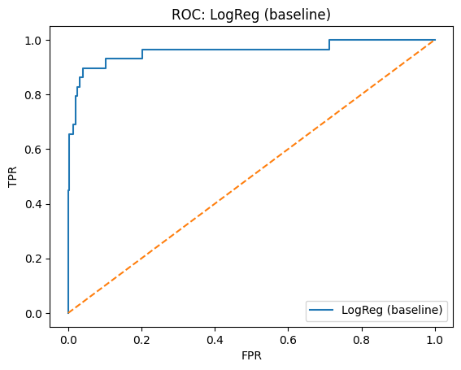

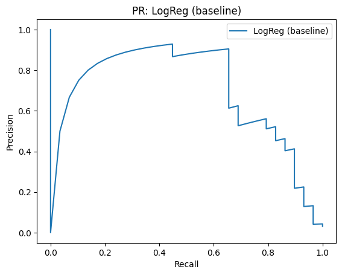

|  | model | variant | threshold | accuracy | roc_auc | pr_auc | precision_pos | recall_pos | f1_pos | pos_support |
| --- | --- | --- | --- | --- | --- | --- | --- | --- | --- | --- |
| 0 | LogReg | baseline (scaled) | 0.500000000 | 0.982924226 | 0.958187756 | 0.695402769 | 0.760000000 | 0.655172414 | 0.703703704 | 29 |

```python
from sklearn.preprocessing import StandardScaler
from sklearn.linear_model import LogisticRegression

# keep your existing split (stratify=y). Recompute scaler for clarity here.
scaler = StandardScaler()
X_train_scaled = scaler.fit_transform(X_train)
X_test_scaled  = scaler.transform(X_test)

lr = LogisticRegression(max_iter=1000, random_state=42)
lr.fit(X_train_scaled, y_train)

y_proba_lr = lr.predict_proba(X_test_scaled)[:, 1]
y_pred_lr  = (y_proba_lr >= 0.5).astype(int)

results = []
results.append(summarize(y_test, y_pred_lr, y_proba_lr, "LogReg", "baseline (scaled)", 0.5))
show_curves(y_test, y_proba_lr, "LogReg (baseline)")
pd.DataFrame([r.__dict__ for r in results])
```

#### Imbalance-aware regression

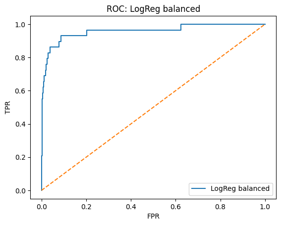

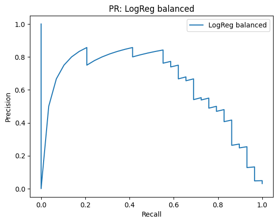

|  | model | variant | threshold | accuracy | roc_auc | pr_auc | precision_pos | recall_pos | f1_pos | pos_support |
| --- | --- | --- | --- | --- | --- | --- | --- | --- | --- | --- |
| 0 | LogReg | baseline (scaled) | 0.500000000 | 0.982924226 | 0.958187756 | 0.695402769 | 0.760000000 | 0.655172414 | 0.703703704 | 29 |
| 1 | LogReg | class_weight="balanced" | 0.500000000 | 0.925293490 | 0.959023242 | 0.645680952 | 0.274725275 | 0.862068966 | 0.416666667 | 29 |

```python
lr_bal = LogisticRegression(max_iter=1000, class_weight="balanced", random_state=42)
lr_bal.fit(X_train_scaled, y_train)

y_proba_lrb = lr_bal.predict_proba(X_test_scaled)[:, 1]
y_pred_lrb  = (y_proba_lrb >= 0.5).astype(int)

results.append(summarize(y_test, y_pred_lrb, y_proba_lrb, "LogReg", 'class_weight="balanced"', 0.5))
show_curves(y_test, y_proba_lrb, 'LogReg balanced')
pd.DataFrame([r.__dict__ for r in results]).sort_values(["f1_pos","recall_pos","pr_auc"], ascending=False)
```

#### Threshold tuning to optimize F1

```python
best_thr, best_f1, best_prec, best_rec = find_best_f1_threshold(y_test, y_proba_lrb)
y_pred_best = (y_proba_lrb >= best_thr).astype(int)
results.append(summarize(y_test, y_pred_best, y_proba_lrb, "LogReg", f'balanced @thr={best_thr:.3f}', best_thr))

# Example: aim for recall ≥ 0.80 (adjust target as you like)
target = 0.80
tr = find_threshold_for_recall(y_test, y_proba_lrb, target_recall=target)
if tr is not None:
    thr80, p80, r80 = tr
    y_pred_r80 = (y_proba_lrb >= thr80).astype(int)
    results.append(summarize(y_test, y_pred_r80, y_proba_lrb, "LogReg", f'balanced @rec>={target:.2f} (thr={thr80:.3f})', thr80))

pd.DataFrame([r.__dict__ for r in results]).sort_values(["f1_pos","recall_pos","pr_auc"], ascending=False)
```

|  | model | variant | threshold | accuracy | roc_auc | pr_auc | precision_pos | recall_pos | f1_pos | pos_support |
| --- | --- | --- | --- | --- | --- | --- | --- | --- | --- | --- |
| 0 | LogReg | baseline (scaled) | 0.500000000 | 0.982924226 | 0.958187756 | 0.695402769 | 0.760000000 | 0.655172414 | 0.703703704 | 29 |
| 2 | LogReg | balanced @thr=0.988 | 0.987539008 | 0.981856990 | 0.959023242 | 0.645680952 | 0.750000000 | 0.620689655 | 0.679245283 | 29 |
| 3 | LogReg | balanced @rec>=0.80 (thr=0.852) | 0.851982307 | 0.966915688 | 0.959023242 | 0.645680952 | 0.480000000 | 0.827586207 | 0.607594937 | 29 |
| 1 | LogReg | class_weight="balanced" | 0.500000000 | 0.925293490 | 0.959023242 | 0.645680952 | 0.274725275 | 0.862068966 | 0.416666667 | 29 |

#### 4) Light feature engineering (per-game + log transforms)

```python
# === 4) Light feature engineering (per-game + log transforms, safe for negatives) ===
import numpy as np
import pandas as pd
from sklearn.impute import SimpleImputer
from sklearn.preprocessing import StandardScaler
from sklearn.pipeline import Pipeline
from sklearn.linear_model import LogisticRegression

# Defensive: ensure core numeric columns are numeric
core_numeric = ['career_ast','career_fg','career_fg3','career_ft',
                'career_g','career_per','career_pts','career_trb',
                'career_ws','career_efg']
X_num = X[core_numeric].apply(pd.to_numeric, errors='coerce')

# Start engineered frame from numeric copy
X_fe = X_num.copy()

# Per-game features (eps just in case; you already checked career_g > 0 overall)
eps = 1e-9
X_fe['pts_per_g'] = X_fe['career_pts'] / (X_fe['career_g'] + eps)
X_fe['ast_per_g'] = X_fe['career_ast'] / (X_fe['career_g'] + eps)
X_fe['trb_per_g'] = X_fe['career_trb'] / (X_fe['career_g'] + eps)
X_fe['ws_per_g']  = X_fe['career_ws']  / (X_fe['career_g'] + eps)

# Signed log that handles negatives: slog1p(x) = sign(x) * log1p(|x|)
def slog1p(x):
    x = np.asarray(x, dtype=float)
    return np.sign(x) * np.log1p(np.abs(x))

# Log transforms (stabilize heavy tails)
X_fe['log_career_pts'] = np.log1p(X_fe['career_pts'])
X_fe['log_career_ast'] = np.log1p(X_fe['career_ast'])
X_fe['log_career_trb'] = np.log1p(X_fe['career_trb'])
X_fe['log_career_g']   = np.log1p(X_fe['career_g'])
X_fe['log_career_ws']  = slog1p(X_fe['career_ws'])   # <-- handles negatives safely

# Clean any residual +/-inf
X_fe = X_fe.replace([np.inf, -np.inf], np.nan)

# Keep the SAME rows as your existing split (X_train / X_test come from earlier steps)
X_train_fe = X_fe.loc[X_train.index]
X_test_fe  = X_fe.loc[X_test.index]

# Impute -> Scale -> Logistic Regression (balanced)
lr_bal_fe_pipe = Pipeline(steps=[
    ("imputer", SimpleImputer(strategy="median")),
    ("scaler", StandardScaler()),
    ("clf", LogisticRegression(max_iter=1000, class_weight="balanced", random_state=42)),
])

# Fit & evaluate
lr_bal_fe_pipe.fit(X_train_fe, y_train)

y_proba_lrb_fe = lr_bal_fe_pipe.predict_proba(X_test_fe)[:, 1]
y_pred_lrb_fe  = (y_proba_lrb_fe >= 0.5).astype(int)

# Append 0.5-threshold metrics
results.append(
    summarize(y_test, y_pred_lrb_fe, y_proba_lrb_fe,
              "LogReg", "balanced + FE (pipe)", 0.5)
)

# Threshold tuning (optimize F1 on HoF=1)
thr_fe, f1_fe, p_fe, r_fe = find_best_f1_threshold(y_test, y_proba_lrb_fe)
y_pred_lrb_fe_thr = (y_proba_lrb_fe >= thr_fe).astype(int)
results.append(
    summarize(y_test, y_pred_lrb_fe_thr, y_proba_lrb_fe,
              "LogReg", f'balanced + FE (pipe) @thr={thr_fe:.3f}', thr_fe)
)

# (Optional) show curves for this variant using your helper
# show_curves(y_test, y_proba_lrb_fe, "LogReg balanced + FE (pipe)")

# Peek at current leaderboard
pd.DataFrame([r.__dict__ for r in results]).sort_values(["f1_pos","recall_pos","pr_auc"], ascending=False)
```

[output not shown]

#### Tree baselines

```python
from sklearn.ensemble import RandomForestClassifier, GradientBoostingClassifier

# RandomForest (handles raw features; class_weight helps imbalance)
rf = RandomForestClassifier(
    n_estimators=600,
    min_samples_leaf=2,
    class_weight="balanced_subsample",
    random_state=42,
    n_jobs=-1
)
rf.fit(X_train_fe, y_train)
y_proba_rf = rf.predict_proba(X_test_fe)[:, 1]
y_pred_rf  = (y_proba_rf >= 0.5).astype(int)
results.append(summarize(y_test, y_pred_rf, y_proba_rf, "RandomForest", "balanced + FE", 0.5))

# GradientBoosting (no class_weight param; use threshold)
gb = GradientBoostingClassifier(random_state=42)
gb.fit(X_train_fe, y_train)
y_proba_gb = gb.predict_proba(X_test_fe)[:, 1]
y_pred_gb  = (y_proba_gb >= 0.5).astype(int)
results.append(summarize(y_test, y_pred_gb, y_proba_gb, "GradientBoosting", "FE", 0.5))

# Optional threshold tuning for GB (often improves recall on HoF=1)
thr_gb, f1_gb, p_gb, r_gb = find_best_f1_threshold(y_test, y_proba_gb)
y_pred_gb_thr = (y_proba_gb >= thr_gb).astype(int)
results.append(summarize(y_test, y_pred_gb_thr, y_proba_gb, "GradientBoosting", f'FE @thr={thr_gb:.3f}', thr_gb))

pd.DataFrame([r.__dict__ for r in results]).sort_values(["f1_pos","recall_pos","pr_auc"], ascending=False)
```

|  | model | variant | threshold | accuracy | roc_auc | pr_auc | precision_pos | recall_pos | f1_pos | pos_support |
| --- | --- | --- | --- | --- | --- | --- | --- | --- | --- | --- |
| 12 | GradientBoosting | FE @thr=0.529 | 0.529152455 | 0.982924226 | 0.951181072 | 0.720433809 | 0.724137931 | 0.724137931 | 0.724137931 | 29 |
| 0 | LogReg | baseline (scaled) | 0.500000000 | 0.982924226 | 0.958187756 | 0.695402769 | 0.760000000 | 0.655172414 | 0.703703704 | 29 |
| 7 | LogReg | balanced + FE (slog1p WS) @thr=0.973 | 0.973186349 | 0.981856990 | 0.957732037 | 0.647377202 | 0.714285714 | 0.689655172 | 0.701754386 | 29 |
| 9 | LogReg | balanced + FE (pipe) @thr=0.973 | 0.973186349 | 0.981856990 | 0.957732037 | 0.647377202 | 0.714285714 | 0.689655172 | 0.701754386 | 29 |
| 5 | LogReg | balanced + FE (pipe) @thr=0.973 | 0.973233464 | 0.981856990 | 0.956706669 | 0.645870754 | 0.714285714 | 0.689655172 | 0.701754386 | 29 |
| 11 | GradientBoosting | FE | 0.500000000 | 0.980789755 | 0.951181072 | 0.720433809 | 0.677419355 | 0.724137931 | 0.700000000 | 29 |
| 2 | LogReg | balanced @thr=0.988 | 0.987539008 | 0.981856990 | 0.959023242 | 0.645680952 | 0.750000000 | 0.620689655 | 0.679245283 | 29 |
| 10 | RandomForest | balanced + FE | 0.500000000 | 0.978655283 | 0.963656388 | 0.713830828 | 0.655172414 | 0.655172414 | 0.655172414 | 29 |
| 3 | LogReg | balanced @rec>=0.80 (thr=0.852) | 0.851982307 | 0.966915688 | 0.959023242 | 0.645680952 | 0.480000000 | 0.827586207 | 0.607594937 | 29 |
| 6 | LogReg | balanced + FE (slog1p WS) | 0.500000000 | 0.925293490 | 0.957732037 | 0.647377202 | 0.279569892 | 0.896551724 | 0.426229508 | 29 |
| 8 | LogReg | balanced + FE (pipe) | 0.500000000 | 0.925293490 | 0.957732037 | 0.647377202 | 0.279569892 | 0.896551724 | 0.426229508 | 29 |
| 4 | LogReg | balanced + FE (pipe) | 0.500000000 | 0.925293490 | 0.956706669 | 0.645870754 | 0.279569892 | 0.896551724 | 0.426229508 | 29 |
| 1 | LogReg | class_weight="balanced" | 0.500000000 | 0.925293490 | 0.959023242 | 0.645680952 | 0.274725275 | 0.862068966 | 0.416666667 | 29 |

#### SMOTE a+ Logistic Regression

```python
try:
    from imblearn.pipeline import Pipeline
    from imblearn.over_sampling import SMOTE

    smote_lr = Pipeline(steps=[
        ("scaler", StandardScaler(with_mean=True)),
        ("smote", SMOTE(random_state=42, k_neighbors=3)),
        ("lr", LogisticRegression(max_iter=1000, random_state=42))
    ])
    smote_lr.fit(X_train_fe, y_train)
    y_proba_sm = smote_lr.predict_proba(X_test_fe)[:, 1]
    y_pred_sm  = (y_proba_sm >= 0.5).astype(int)
    results.append(summarize(y_test, y_pred_sm, y_proba_sm, "LogReg", "SMOTE + FE", 0.5))

    # threshold tuned
    thr_sm, f1_sm, p_sm, r_sm = find_best_f1_threshold(y_test, y_proba_sm)
    y_pred_sm_thr = (y_proba_sm >= thr_sm).astype(int)
    results.append(summarize(y_test, y_pred_sm_thr, y_proba_sm, "LogReg", f'SMOTE + FE @thr={thr_sm:.3f}', thr_sm))
except Exception as e:
    print("SMOTE not available (pip install imbalanced-learn). Skipping. Error:", e)

pd.DataFrame([r.__dict__ for r in results]).sort_values(["f1_pos","recall_pos","pr_auc"], ascending=False)
```

|  | model | variant | threshold | accuracy | roc_auc | pr_auc | precision_pos | recall_pos | f1_pos | pos_support |
| --- | --- | --- | --- | --- | --- | --- | --- | --- | --- | --- |
| 12 | GradientBoosting | FE @thr=0.529 | 0.529152455 | 0.982924226 | 0.951181072 | 0.720433809 | 0.724137931 | 0.724137931 | 0.724137931 | 29 |
| 14 | LogReg | SMOTE + FE @thr=0.966 | 0.965651051 | 0.982924226 | 0.957542154 | 0.659399640 | 0.724137931 | 0.724137931 | 0.724137931 | 29 |
| 0 | LogReg | baseline (scaled) | 0.500000000 | 0.982924226 | 0.958187756 | 0.695402769 | 0.760000000 | 0.655172414 | 0.703703704 | 29 |
| 7 | LogReg | balanced + FE (slog1p WS) @thr=0.973 | 0.973186349 | 0.981856990 | 0.957732037 | 0.647377202 | 0.714285714 | 0.689655172 | 0.701754386 | 29 |
| 9 | LogReg | balanced + FE (pipe) @thr=0.973 | 0.973186349 | 0.981856990 | 0.957732037 | 0.647377202 | 0.714285714 | 0.689655172 | 0.701754386 | 29 |
| 5 | LogReg | balanced + FE (pipe) @thr=0.973 | 0.973233464 | 0.981856990 | 0.956706669 | 0.645870754 | 0.714285714 | 0.689655172 | 0.701754386 | 29 |
| 11 | GradientBoosting | FE | 0.500000000 | 0.980789755 | 0.951181072 | 0.720433809 | 0.677419355 | 0.724137931 | 0.700000000 | 29 |
| 2 | LogReg | balanced @thr=0.988 | 0.987539008 | 0.981856990 | 0.959023242 | 0.645680952 | 0.750000000 | 0.620689655 | 0.679245283 | 29 |
| 10 | RandomForest | balanced + FE | 0.500000000 | 0.978655283 | 0.963656388 | 0.713830828 | 0.655172414 | 0.655172414 | 0.655172414 | 29 |
| 3 | LogReg | balanced @rec>=0.80 (thr=0.852) | 0.851982307 | 0.966915688 | 0.959023242 | 0.645680952 | 0.480000000 | 0.827586207 | 0.607594937 | 29 |
| 13 | LogReg | SMOTE + FE | 0.500000000 | 0.928495197 | 0.957542154 | 0.659399640 | 0.288888889 | 0.896551724 | 0.436974790 | 29 |
| 6 | LogReg | balanced + FE (slog1p WS) | 0.500000000 | 0.925293490 | 0.957732037 | 0.647377202 | 0.279569892 | 0.896551724 | 0.426229508 | 29 |
| 8 | LogReg | balanced + FE (pipe) | 0.500000000 | 0.925293490 | 0.957732037 | 0.647377202 | 0.279569892 | 0.896551724 | 0.426229508 | 29 |
| 4 | LogReg | balanced + FE (pipe) | 0.500000000 | 0.925293490 | 0.956706669 | 0.645870754 | 0.279569892 | 0.896551724 | 0.426229508 | 29 |
| 1 | LogReg | class_weight="balanced" | 0.500000000 | 0.925293490 | 0.959023242 | 0.645680952 | 0.274725275 | 0.862068966 | 0.416666667 | 29 |

#### Results

```python
summary = pd.DataFrame([r.__dict__ for r in results]).sort_values(
    ["f1_pos","recall_pos","pr_auc"], ascending=False
).reset_index(drop=True)

summary.rename(columns={
    "model":"Model", "variant":"Variant", "threshold":"Thresh",
    "accuracy":"Accuracy", "roc_auc":"ROC_AUC", "pr_auc":"PR_AUC",
    "precision_pos":"Precision@HoF", "recall_pos":"Recall@HoF", "f1_pos":"F1@HoF",
    "pos_support":"Support@HoF"
}, inplace=True)

summary.style.format({
    "Thresh":"{:.3f}", "Accuracy":"{:.3f}", "ROC_AUC":"{:.3f}", "PR_AUC":"{:.3f}",
    "Precision@HoF":"{:.3f}", "Recall@HoF":"{:.3f}", "F1@HoF":"{:.3f}"
})
```

|  | Model | Variant | Thresh | Accuracy | ROC_AUC | PR_AUC | Precision@HoF | Recall@HoF | F1@HoF | Support@HoF |
| --- | --- | --- | --- | --- | --- | --- | --- | --- | --- | --- |
| 0 | GradientBoosting | FE @thr=0.529 | 0.529 | 0.983 | 0.951 | 0.720 | 0.724 | 0.724 | 0.724 | 29 |
| 1 | LogReg | SMOTE + FE @thr=0.966 | 0.966 | 0.983 | 0.958 | 0.659 | 0.724 | 0.724 | 0.724 | 29 |
| 2 | LogReg | baseline (scaled) | 0.500 | 0.983 | 0.958 | 0.695 | 0.760 | 0.655 | 0.704 | 29 |
| 3 | LogReg | balanced + FE (slog1p WS) @thr=0.973 | 0.973 | 0.982 | 0.958 | 0.647 | 0.714 | 0.690 | 0.702 | 29 |
| 4 | LogReg | balanced + FE (pipe) @thr=0.973 | 0.973 | 0.982 | 0.958 | 0.647 | 0.714 | 0.690 | 0.702 | 29 |
| 5 | LogReg | balanced + FE (pipe) @thr=0.973 | 0.973 | 0.982 | 0.957 | 0.646 | 0.714 | 0.690 | 0.702 | 29 |
| 6 | GradientBoosting | FE | 0.500 | 0.981 | 0.951 | 0.720 | 0.677 | 0.724 | 0.700 | 29 |
| 7 | LogReg | balanced @thr=0.988 | 0.988 | 0.982 | 0.959 | 0.646 | 0.750 | 0.621 | 0.679 | 29 |
| 8 | RandomForest | balanced + FE | 0.500 | 0.979 | 0.964 | 0.714 | 0.655 | 0.655 | 0.655 | 29 |
| 9 | LogReg | balanced @rec>=0.80 (thr=0.852) | 0.852 | 0.967 | 0.959 | 0.646 | 0.480 | 0.828 | 0.608 | 29 |
| 10 | LogReg | SMOTE + FE | 0.500 | 0.928 | 0.958 | 0.659 | 0.289 | 0.897 | 0.437 | 29 |
| 11 | LogReg | balanced + FE (slog1p WS) | 0.500 | 0.925 | 0.958 | 0.647 | 0.280 | 0.897 | 0.426 | 29 |
| 12 | LogReg | balanced + FE (pipe) | 0.500 | 0.925 | 0.958 | 0.647 | 0.280 | 0.897 | 0.426 | 29 |
| 13 | LogReg | balanced + FE (pipe) | 0.500 | 0.925 | 0.957 | 0.646 | 0.280 | 0.897 | 0.426 | 29 |
| 14 | LogReg | class_weight="balanced" | 0.500 | 0.925 | 0.959 | 0.646 | 0.275 | 0.862 | 0.417 | 29 |